**Classification**

Table of Contents

# 1. Classification

```python
from IPython.display import YouTubeVideo
YouTubeVideo('IRrGVQV8vZ8?si=_hkRnh2jEhJVDXsY&amp;start=931', width = "560", height = "315")
```

[video not shown]

Classification is an another core task in machine learning, aimed at categorizing data into predefined classes or categories based on input features. Unlike regression, where the target variable is continuous, classification deals with discrete outputs. It plays a crucial role in a variety of real-world applications, such as

- Spam detection: Classifying emails as either spam or not spam
- Image recognition: Identifying objects, animals, or faces in images
- Medical diagnosis: Predicting whether a patient has a particular condition based on diagnostic data

**Key Characteristics of Classification**

- The output variable $y$ is discrete and often categorical.
- The goal is to develop a model that accurately determines the class to which a new input belongs.
- Classification models are evaluated based on their ability to correctly predict class labels for unseen data.

(1) Binary Classification:

- Involves two classes (e.g., spam vs. non-spam, positive vs. negative).
- Often employs decision boundaries to separate the two categories.

(2) Multiclass Classification:

- Involves more than two classes (e.g., classifying handwritten digits from 0 to 9).
- Typically treated as an extension of binary classification by combining multiple binary classifiers.

**Topics Covered in This Section**

To build a solid understanding of classification techniques, we will explore the following key algorithms:

(1) Perceptron:

- A foundational algorithm inspired by biological neurons, ideal for linearly separable data.

(2) Support Vector Machines (SVM):

- A powerful technique that identifies the optimal hyperplane to maximize the margin between different classes.

(3) Logistic Regression:

- A widely used method for binary classification that models the probability of class membership using the logistic function.

# 2. Perceptron

The Perceptron is one of the simplest types of artificial neural networks and is used for binary classification. It was invented by [Frank Rosenblatt](https://en.wikipedia.org/wiki/Frank_Rosenblatt) in 1958 and serves as the foundation for more advanced neural networks.

To understand how the perceptron works, let's consider a bank loan approval scenario where the bank decides whether to approve or reject a loan application based on specific criteria.

- For input $x = \begin{bmatrix}x_1\\ \vdots\\ x_d \end{bmatrix}\;$ 'attributes (or features) of a customer'
- weights $\omega = \begin{bmatrix}\omega_1\\ \vdots\\ \omega_d \end{bmatrix}$

Suppose a decision can be made based on a simple linear combination of features:

$$\begin{align*} \text{Approve credit if} \; & \sum\limits_{i=1}^{d}\omega_ix_i > \text{threshold}, \\ \text{Deny credit if} \; & \sum\limits_{i=1}^{d}\omega_ix_i < \text{threshold}. \end{align*}$$

$$g(x) = \text{sign} \left(\left( \sum\limits_{i=1}^{d}\omega_ix_i \right)- \text{threshold} \right) = \text{sign}\left(\left( \sum\limits_{i=1}^{d}\omega_ix_i \right)+ \omega_0\right)$$

where a sign function is:

$$ \text{sign}(x) = \begin{cases} 1, &\text{if }\; x > 0\\ 0, &\text{if }\; x = 0\\ -1, &\text{if }\; x < 0 \end{cases} $$

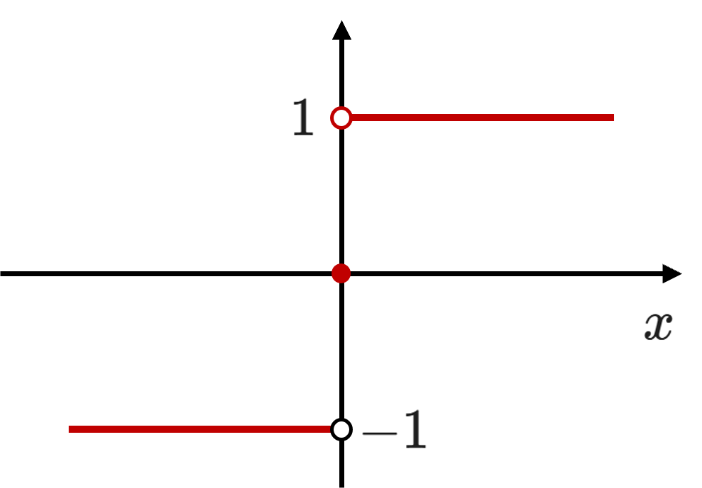

Introduce an artificial coordinate $x_0 = 1$:

- To simplify the perceptron formulation, we can include the bias term $\omega_0$ into the weight vector by adding an artificial coordinate $x_0 = 1$ to the input vector $x$. This eliminates the explicit bias term and simplifies the computation.

$$g(x) = \text{sign}\left( \sum\limits_{\color{red}{i=0}}^{d}\omega_ix_i \right)$$

In a vector form

$$g(x) = \text{sign}\left( \omega^T x \right)$$

Classification boundary: hyperplane $g(x) = 0 \implies \omega^T x = 0$

- Separates a D-dimensional space into two half-spaces
- Defined by an outward pointing normal vector $\omega$
- Assume the hyperplane passes through origin, $\omega^T x = 0$ with $x_0 = 1$
- $\omega$ is orthogonal to any vector lying on the hyperplane

$$ \begin{align*} \omega = \begin{bmatrix}\omega_1 \\ \omega_2 \end{bmatrix}, \quad x = \begin{bmatrix} x_1 \\ x_2\end{bmatrix} &\implies g(x) = \omega_0 + \omega_1 x_1 + \omega_2 x_2 = \omega_0 + \omega^T x \qquad \text{or}\\\\\\ \omega = \begin{bmatrix}\omega_0 \\ \omega_1 \\ \omega_2 \end{bmatrix}, \quad x = \begin{bmatrix} 1 \\ x_1 \\ x_2\end{bmatrix} &\implies g(x) = \omega_0 + \omega_1 x_1 + \omega_2 x_2 = \omega^T x \end{align*} $$

Given the vector $ \omega $, the decision boundary is defined by the hyperplane:

$$ \omega^T x = 0 $$

This hyperplane is orthogonal to the vector $ \omega $, meaning $ \omega $ determines the direction perpendicular to the boundary.

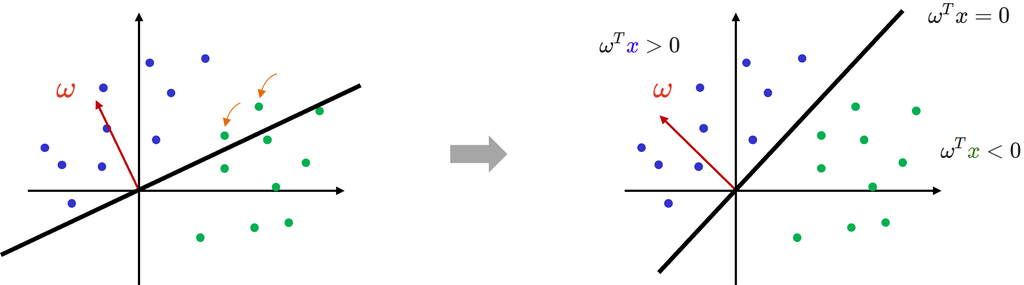

- Blue Points: Since all blue points are located on the same side of the hyperplane relative to $ \omega $, they satisfy:

  $$ \omega^T x > 0 $$
  This corresponds to the region where $ g(x) > 0 $, classifying these points as belonging to Class 1.
- Green Points: Conversely, the green points are positioned on the opposite side of the hyperplane relative to $ \omega $, satisfying:

  $$ \omega^T x < 0 $$
  This corresponds to the region where $ g(x) < 0 $, classifying these points as belonging to Class 0.

In this linear classification framework, $ \omega $ not only defines the orientation of the boundary but also plays a crucial role in determining which points belong to each class based on their position relative to the hyperplane.

**Learning a Hyperplane for Classification**

(1) Goal:

The objective is to learn the hyperplane $g_{\omega}(x)=0$ using the given training data. This hyperplane serves as the decision boundary that separates different classes.

(2) How to find $\omega$:

The parameter vector $\omega$ defines the orientation and position of the hyperplane. The classification rule is determined as follows:

- For all data points belonging to Class 1:

$$g(x) > 0$$

- For all data points belonging to Class 0:

$$g(x) < 0$$

This formulation highlights the fundamental idea behind linear classifiers, where the decision boundary is defined by a linear function of the input features. By appropriately determining $\omega$, we can effectively separate the data points into their respective classes.

Note that in traditional methods, the vector $\omega$ is often determined by domain experts based on their prior knowledge and insights about the system. However, in machine learning, the objective is to estimate $\omega$ directly from the data without any inherent bias or preconception. This data-driven approach allows the model to adaptively learn the optimal decision boundary, potentially uncovering complex patterns that may not be apparent through manual design.

**Key Insights**

- 'Learning from Data' as a Paradigm Shift:

  The concept of "learning from data" represents a significant philosophical shift for many engineers. Traditional engineering methods often rely on explicitly defined models and expert-derived parameters. In contrast, machine learning emphasizes empirical learning, where patterns and relationships are discovered directly from observed data.
- Estimating $\omega$:

  There are various techniques available to estimate $\omega$, each designed to suit different types of data and modeling requirements. We will explore several key algorithms for effectively estimating $\omega$. These methods form the foundation of machine learning approaches to classification.

## 2.1. Perceptron Algorithm

We will first walk through the perceptron algorithm and then explore the underlying principles that explain how and why it works.

The perceptron implements

$$h(x) = \text{sign}\left( \omega^Tx \right)$$

Given the training set

$$(x_1, y_1), (x_2, y_2), \cdots, (x_N, y_N) \quad \text{where } y_i \in \{-1,1\}$$

1. pick a misclassified point

$$ \text{sign}\left(\omega^Tx_n \right) \neq y_n$$

2. and update the weight vector

$$\omega \leftarrow \omega + y_nx_n$$

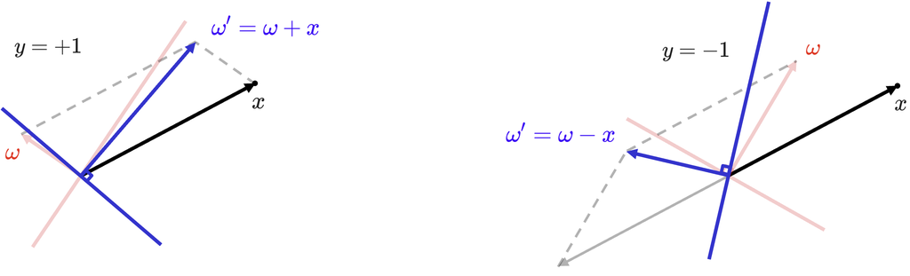

**Why Perceptron Updates Work ?**

- Let's look at a misclassified positive example ($y_n = +1$)
  - perceptron (wrongly) thinks $\omega_{old}^T x_n < 0$
- Updates would be

$$ \begin{align*}\omega_{new} &= \omega_{old} + y_n x_n = \omega_{old} + x_n \\ \\ \omega_{new}^T x_n &= (\omega_{old} + x_n)^T x_n = \omega_{old}^T x_n + x_n^T x_n \geq \omega_{old}^T x_n \end{align*}$$

- Thus $\omega_{new}^T x_n$ is less negative than $\omega_{old}^T x_n$

Note:

(1) Perceptron Update Rule (discrete version):

$$\omega \leftarrow \omega \pm 1 \cdot x_n$$

(2) Gradient Descent Update Rule (continuous version):

$$\omega \leftarrow \omega - \alpha \nabla_{\omega} f$$

Understanding this similarity provides insight into the foundational mechanisms of various learning algorithms, illustrating how they iteratively adjust model parameters to enhance performance.

**Summary**

The perceptron is a simple yet powerful model for binary classification tasks like bank loan approval. It classifies applicants based on features like credit score, income, and debt. While it works well for linearly separable data, it has limitations for more complex datasets. Understanding how the perceptron learns and updates its weights is fundamental to understanding modern neural networks.

(1) Input Stage

- The model takes multiple inputs, denoted as $ x_0, x_1, \cdots, x_d $, each associated with a corresponding weight $ \omega_0, w_1, \cdots, w_d $.
- These weights are key parameters that the model adjusts during the learning process.

(2) Weighted Sum Calculation

- Each input is multiplied by its respective weight, and the results are summed:

$$ z = \omega_0 x_0 + w_1 x_1 + \cdots + w_d x_d $$

(3) Activation Function

- The summation result $ z $ is passed through the sign function, which determines the predicted output:

$$ \hat{y} = \text{sign}(z) $$

- The sign function outputs either $ +1 $ or $ -1 $, representing the two possible classes in binary classification.

(4) Weight Update (Learning Process)

- The predicted output $ \hat{y} $ is compared with the true label $ y $.
- If the prediction is incorrect, the weights are updated as follows:

$$ \omega \leftarrow \omega + y_n x_n $$

- This iterative adjustment is the foundation of the Perceptron Learning Algorithm, ensuring that the decision boundary improves over time based on the training data — a clear example of data-driven learning.

**Important Insight for Deep Learning**

**Perceptron loss function**

If you do not want to explicitly check whether each point is misclassified or not, you can write the perceptron loss function in a more compact expression that automatically accumulates contributions only from misclassified points.

The loss for an individual sample is defined as:

$$ \mathscr{L}(\omega) = \max \left\{ 0, -y_n \cdot \left(\omega^T x_n \right)\right\} $$

- Loss $\mathscr{L}(\omega) = 0$ on examples where perceptron is correct, i.e., $y_n \cdot \left(\omega^T x_n \right) > 0$
- Loss $\mathscr{L}(\omega) > 0$ on examples where perceptron misclassified, i.e., $y_n \cdot \left(\omega^T x_n \right) < 0$

Note:

- $\text{sign}\left(\omega^T x_n \right) \neq y_n$ is equivalent to $ y_n \cdot \left(\omega^T x_n \right) < 0$
- $\text{ReLU}(z) = \max(0, z)$: the Rectified Linear Unit (ReLU) will be revisited later in the discussion, as it plays a crucial role not only in perceptron loss formulation but also in modern deep learning architectures where it is widely used as an activation function.

This function returns zero when the point is correctly classified and returns a positive value proportional to the margin violation when misclassified.

**Compact Expression for Total Perceptron Loss**

The total loss across all samples in the dataset $D$ is given by:

$$ \mathscr{L}(\omega) = \sum_{n =1}^{m} \max \left\{ 0, -y_n \cdot \left(\omega^T x_n \right)\right\} $$

This summation aggregates the loss over all training samples and only penalizes incorrectly classified points.

## 2.2. Perceptron in Python

By adding an artificial coordinate $x_0 = 1$, we simplify the perceptron implementation and avoid the need to handle the bias separately. This technique is commonly used in machine learning to streamline calculations and make the formulation more uniform.

$$g(x) = \omega_0 + \omega^Tx = \omega_0 + \omega_1x_1 + \omega_2x_2 = 0$$

$$ \begin{align*} \omega &= \begin{bmatrix} \omega_0 \\ \omega_1 \\ \omega_2\end{bmatrix}\\ \\ x &= \begin{bmatrix} \left(x^{(1)}\right)^T \\ \left(x^{(2)}\right)^T \\ \left(x^{(3)}\right)^T\\ \vdots \\ \left(x^{(m)}\right)^T \end{bmatrix} = \begin{bmatrix} 1 & x_1^{(1)} & x_2^{(1)} \\ 1 & x_1^{(2)} & x_2^{(2)} \\ 1 & x_1^{(3)} & x_2^{(3)}\\\vdots & \vdots & \vdots \\ 1 & x_1^{(m)} & x_2^{(m)}\end{bmatrix} \\ \\ y &= \begin{bmatrix}y^{(1)} \\ y^{(2)} \\ y^{(3)}\\ \vdots \\ y^{(m)} \end{bmatrix} \end{align*}$$

```python
import numpy as np
import matplotlib.pyplot as plt
%matplotlib inline
```

```python
#training data gerneration
m = 100
x1 = 8*np.random.rand(m, 1)
x2 = 7*np.random.rand(m, 1) - 4

g = 0.8*x1 + x2 - 3
```

```python
C1 = np.where(g >= 1)
C0 = np.where(g < -1)
print(C1)
```

```
(array([ 5, 14, 16, 18, 19, 30, 32, 33, 34, 36, 46, 47, 52, 53, 56, 61, 64,
       66, 67, 70, 71, 72, 74, 77, 80, 82, 84, 91, 97]), array([0, 0, 0, 0, 0, 0, 0, 0, 0, 0, 0, 0, 0, 0, 0, 0, 0, 0, 0, 0, 0, 0,
       0, 0, 0, 0, 0, 0, 0]))
```

```python
C1 = np.where(g >= 1)[0]
C0 = np.where(g < -1)[0]
print(C1.shape)
print(C0.shape)
```

```
(29,)
(37,)
```

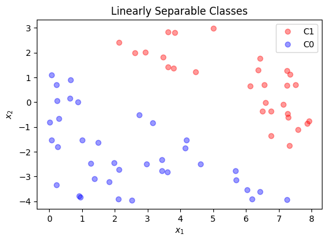

```python
plt.figure(figsize = (6, 4))
plt.plot(x1[C1], x2[C1], 'ro', alpha = 0.4, label = 'C1')
plt.plot(x1[C0], x2[C0], 'bo', alpha = 0.4, label = 'C0')
plt.title('Linearly Separable Classes')
plt.legend(loc = 1)
plt.xlabel(r'$x_1$')
plt.ylabel(r'$x_2$')
plt.show()
```

$$ \begin{align*} x &= \begin{bmatrix} \left(x^{(1)}\right)^T \\ \left(x^{(2)}\right)^T \\ \left(x^{(3)}\right)^T\\ \vdots \\ \left(x^{(m)}\right)^T \end{bmatrix} = \begin{bmatrix} 1 & x_1^{(1)} & x_2^{(1)} \\ 1 & x_1^{(2)} & x_2^{(2)} \\ 1 & x_1^{(3)} & x_2^{(3)}\\\vdots & \vdots & \vdots \\ 1 & x_1^{(m)} & x_2^{(m)}\end{bmatrix} \\\\ y &= \begin{bmatrix}y^{(1)} \\ y^{(2)} \\ y^{(3)}\\ \vdots \\ y^{(m)} \end{bmatrix} \end{align*}$$

```python
X1 = np.hstack([np.ones([C1.shape[0],1]), x1[C1], x2[C1]])
X0 = np.hstack([np.ones([C0.shape[0],1]), x1[C0], x2[C0]])
X = np.vstack([X1, X0])

y = np.vstack([np.ones([C1.shape[0],1]), -np.ones([C0.shape[0],1])])

X = np.asmatrix(X)
y = np.asmatrix(y)
```

$$\omega = \begin{bmatrix} \omega_0 \\ \omega_1 \\ \omega_2\end{bmatrix}$$

$$\omega \leftarrow \omega + yx$$ where $(x, y)$ is a misclassified training point

```python
w = np.ones([3,1])
w = np.asmatrix(w)

n_iter = y.shape[0]
for k in range(n_iter):
    for i in range(n_iter):
        if y[i,0] != np.sign(X[i,:]*w)[0,0]:
            w += y[i,0]*X[i,:].T

print(w)
```

```
[[-8.        ]
 [ 2.99076528]
 [ 5.25407248]]
```

$$ \begin{align*} g(x) &= \omega_0 + \omega^Tx = \omega_0 + \omega_1x_1 + \omega_2x_2 = 0 \\\\ \implies x_2 &= -\frac{\omega_1}{\omega_2} x_1 - \frac{\omega_0}{\omega_2} \end{align*} $$

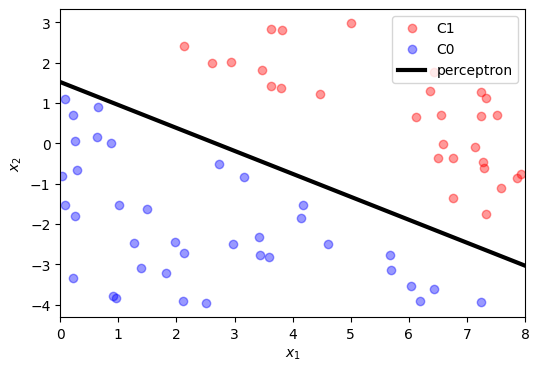

```python
x1p = np.linspace(0,8,100).reshape(-1,1)
x2p = - w[1,0]/w[2,0]*x1p - w[0,0]/w[2,0]

plt.figure(figsize = (6, 4))
plt.plot(x1[C1], x2[C1], 'ro', alpha = 0.4, label = 'C1')
plt.plot(x1[C0], x2[C0], 'bo', alpha = 0.4, label = 'C0')
plt.plot(x1p, x2p, c = 'k', linewidth = 3, label = 'perceptron')
plt.xlim([0, 8])
plt.xlabel('$x_1$')
plt.ylabel('$x_2$')
plt.legend(loc = 1)
plt.show()
```

**Perceptron using Scikit-Learn**

In scikit-learn, the Perceptron includes the bias term by default, so you don't need to add an artificial coordinate manually. This makes it more convenient for implementing and training perceptron models on datasets.

$$ \begin{align*} x &= \begin{bmatrix} \left(x^{(1)}\right)^T \\ \left(x^{(2)}\right)^T \\ \left(x^{(3)}\right)^T\\ \vdots \\ \left(x^{(m)}\right)^T \end{bmatrix} = \begin{bmatrix} x_1^{(1)} & x_2^{(1)} \\ x_1^{(2)} & x_2^{(2)} \\ x_1^{(3)} & x_2^{(3)}\\ \vdots & \vdots \\ x_1^{(m)} & x_2^{(m)}\end{bmatrix} \\\\ y &= \begin{bmatrix}y^{(1)} \\ y^{(2)} \\ y^{(3)}\\ \vdots \\ y^{(m)} \end{bmatrix} \end{align*}$$

```python
X1 = np.hstack([x1[C1], x2[C1]])
X0 = np.hstack([x1[C0], x2[C0]])
X = np.vstack([X1, X0])

y = np.vstack([np.ones([C1.shape[0],1]), -np.ones([C0.shape[0],1])])
```

```python
from sklearn import linear_model

clf = linear_model.Perceptron(tol=1e-3)
clf.fit(X, np.ravel(y))
```

```
Perceptron()
```

```python
clf.predict([[3, -2]])
```

```
array([-1.])
```

```python
clf.predict([[6, 2]])
```

```
array([1.])
```

```python
clf.coef_
```

```
array([[3.28886445, 5.97667198]])
```

```python
clf.intercept_
```

```
array([-8.])
```

$$ \begin{align*} g(x) &= \omega_0 + \omega^Tx = \omega_0 + \omega_1x_1 + \omega_2x_2 = 0 \\\\ \implies x_2 &= -\frac{\omega_1}{\omega_2} x_1 - \frac{\omega_0}{\omega_2} \end{align*} $$

```python
w0 = clf.intercept_[0]
w1 = clf.coef_[0,0]
w2 = clf.coef_[0,1]
```

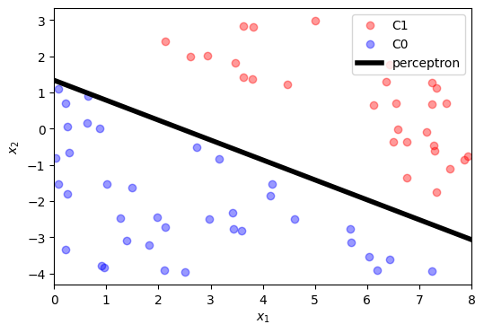

```python
x1p = np.linspace(0,8,100).reshape(-1,1)
x2p = - w1/w2*x1p - w0/w2

plt.figure(figsize = (6, 4))
plt.plot(x1[C1], x2[C1], 'ro', alpha = 0.4, label = 'C1')
plt.plot(x1[C0], x2[C0], 'bo', alpha = 0.4, label = 'C0')
plt.plot(x1p, x2p, c = 'k', linewidth = 4, label = 'perceptron')
plt.xlim([0, 8])
plt.xlabel('$x_1$')
plt.ylabel('$x_2$')
plt.legend(loc = 1)
plt.show()
```

## 2.3. The Best Hyperplane Separator?

**Limitations**

The Perceptron Algorithm successfully identifies a separating hyperplane if the data is linearly separable. However, there are typically many possible hyperplanes that can separate the data. The Perceptron algorithm does not guarantee the optimal hyperplane - it merely finds one of the possible solutions.

**Improvements**

While the Perceptron identifies one valid separating hyperplane, identifying the best hyperplane requires an optimization framework. This concept is crucial in understanding more advanced models like Support Vector Machines (SVM) and Logistic Regression, which are designed to find optimal decision boundaries with improved performance and generalization.

## 2.4. Historical Notes

In the late 1960s, [Marvin Minsky](https://en.wikipedia.org/wiki/Marvin_Minsky) and [Seymour Papert](https://en.wikipedia.org/wiki/Seymour_Papert) published the influential book "Perceptrons" (1969), where they mathematically demonstrated the limitations of the perceptron. One key result from their work was that single-layer perceptrons cannot solve the XOR problem (exclusive OR), highlighting a significant limitation of early neural networks.

Stagnation in Neural Network Research:

- The book led to a significant decline in interest and funding for neural networks, as it was seen as proof that neural networks had severe limitations.
- This period is often referred to as the "AI Winter".

Rediscovery with Multi-Layer Networks:

- In the 1980s, researchers like [Geoffrey Hinton](https://en.wikipedia.org/wiki/Geoffrey_Hinton) showed that multi-layer perceptrons (MLPs) with backpropagation could learn non-linear functions like XOR.
- Adding hidden layers and non-linear activation functions allows neural networks to learn complex, non-linear patterns.

# 3. SVM

As a first classification algorithm that improve upon the simple perceptron, we will study Support Vector Machines (SVM) in this section. To build the foundation for understanding SVMs, we will first examine how to compute the distance from a point to a line. This concept is crucial, as it will later be used to identify and optimize the best possible hyperplane separator.

## 3.1. Distance from a Line

$$\omega = \begin{bmatrix}\omega_1 \\ \omega_2\end{bmatrix}, \, x = \begin{bmatrix}x_1\\x_2\end{bmatrix} \; \implies g(x) = \omega_0 + \omega^Tx = \omega_0 + \omega_1x_1 + \omega_2x_2 $$

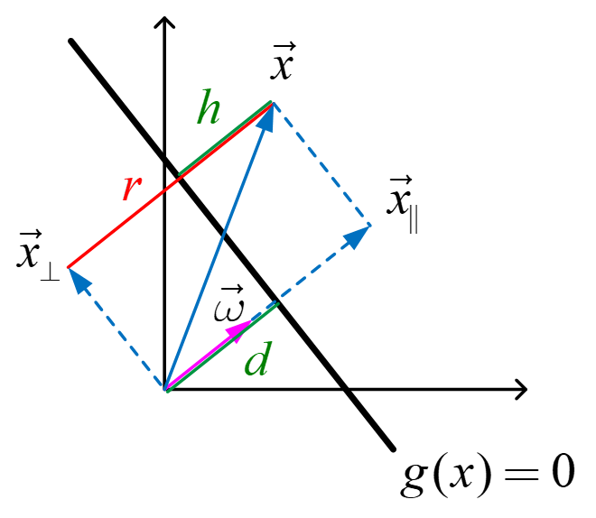

(1) If $\vec p$ and $\vec q$ are on the decision line

$$ \begin{align*} g\left(\vec p\right) = g\left(\vec q\right) = 0 \quad & \implies \quad \omega_0 + \omega^T \vec p = \omega_0 + \omega^T \vec q = 0 \\ & \implies \quad \omega^T \left( \vec p- \vec q \right) = 0 \end{align*} $$

$$ \begin{align*} & \therefore \, \omega : \text{orthogonal to the line} \\ & \implies \text{tells the direction of the line} \end{align*}$$

(2) Compute $d$ which is a normal signed distance from the origin to the line

- If $x$ is on the line and $x = d\frac{\omega}{\lVert \omega \rVert}$ (where $d$ is a normal distance from the origin to the line)

$$ \begin{align*} g(x)& = \omega_0 + \omega^Tx = 0 \; \\ & \Rightarrow \omega_0 + \omega^Td\frac{\omega}{\lVert \omega \rVert} = \omega_0 + d\frac{\omega^T\omega}{\lVert \omega \rVert} = \omega_0 + d\lVert \omega \rVert = 0 \\\\ & \therefore d \, = - \frac{\omega_0}{\lVert \omega \rVert} \end{align*}$$

(3) Compute $h$ which is a normal signed distance from $x$ to the line

- For any vector of $x$

$$ x = x_{\perp} + r \frac{\omega}{\lVert \omega \rVert}$$

$$ \omega^Tx = \omega^T \left( x_{\perp} + r \frac{\omega}{\lVert \omega \rVert}\right) = r \frac{\omega^T\omega}{\lVert \omega \rVert} = r \lVert \omega \rVert$$

$$ \begin{align*} g(x) & = \omega_0 + \omega^Tx \\ & = \omega_0 + r \lVert \omega \rVert \qquad (r = d + h) \\ & = \omega_0 + (d +h) \lVert \omega \rVert\\ & = \omega_0 + \left(- \frac{\omega_0}{\lVert \omega \rVert} + h \right)\lVert \omega \rVert\\ & = h \lVert \omega \rVert \end{align*}$$

$$\therefore \; h = \frac{g(x)}{\lVert \omega \rVert} \implies\; \text{orthogonal signed distance from the line}$$

- $\text{sign}(h)$ indicates whether $x$ is located on the same side of the hyperplane relative to $\omega$ or not.

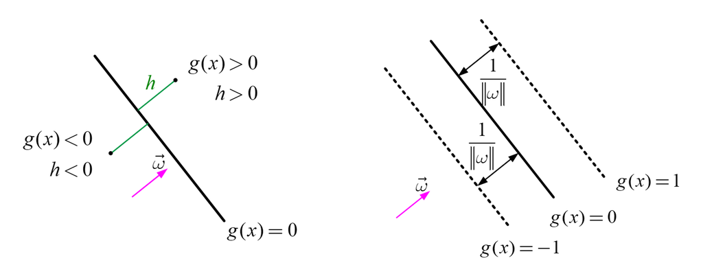

## 3.2. Distance Between Two Parallel Lines $g(x) = -1$ and $g(x) = 1$

(1) Find a distance between $g(x) = -1$ and $g(x) = 1$

- Suppose $g(x_1) = -1,\; g(x_2) = 1$

$$ \begin{align*} h_1 &= \frac{g(x_1)}{\lVert \omega \rVert} = \frac{-1}{\lVert \omega \rVert} \\ h_2 &= \frac{g(x_2)}{\lVert \omega \rVert} = \frac{1}{\lVert \omega \rVert} \\\\ \lvert \; \lvert h_2 \rvert + \lvert h_1 \rvert \; \rvert &= \frac{1}{\lVert \omega \rVert} + \frac{1}{\lVert \omega \rVert} = \frac{2}{\lVert \omega \rVert} \end{align*} $$

- This distance formula is especially important in SVMs, where maximizing the margin between parallel decision boundaries is key to optimal classification.

(2) Another method to find a distance between $g(x) = -1$ and $g(x) = 1$

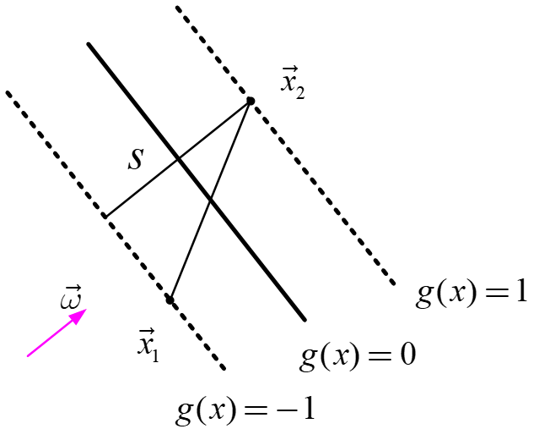

- Suppose $g(x_1) = -1,\; g(x_2) = 1$

$$ \begin{array}{I} \omega_0 + \omega^Tx_1 = -1\\ \omega_0 + \omega^Tx_2 = 1\\ \end{array} \; \implies \; \omega^T(x_2 - x_1) = 2$$

$$s = \langle\frac{\omega}{\lVert \omega \rVert}, \; x_2 - x_1 \rangle = \frac{1}{\lVert \omega \rVert}\omega^T(x_2 - x_1) = \frac {2}{\lVert \omega \rVert}$$